# Laboratorio 05

Pablo González

21/4/2021

```r
if (!require('readr')) install.packages('readr'); library('readr')
if (!require('tidyverse')) install.packages('tidyverse'); library('tidyverse')
if (!require('stringr')) install.packages('stringr'); library('stringr')
if (!require('ggstance')) install.packages('ggstance'); library('ggstance')
if (!require('knitr')) install.packages('knitr'); library('knitr')
if (!require('kableExtra')) install.packages('kableExtra'); library('kableExtra')
```

# Pregunta 1: Caso Pokémon

Luego de una larga travesía, Ash Ketchum (サトシ para los amigos) vuelve a casa con su Pokédex completa. Ésta es luego entregada al profesor Oak para su posterior análisis, quien le pide a usted, que, utilizando sus bastos conocimientos de R, responda las siguientes preguntas:

Primero importamos nuestro set de datos

```r
pokemon <- read_csv("pokemon.csv")
```

## Punto 1

Obtenga el número, nombre, nombre en japonés, clasificación y si es o no legendario, de aquellos Pokémon cuyo ataque triplique su defensa.

```r
pokemon %>%
  filter(attack > 3*defense) %>%
  select(pokedex_number,name,japanese_name,classfication,is_legendary) %>%
    kable(caption = "Tabla 1: Pokémon con Ataque > 3xDefensa",
        digits = 2, align = "l",
        col.names = c("Número","Nombre en Inglés","Nombre en Japonés","Clasificación","Legendario")) %>%
  kable_styling("striped", full_width = T)
```

Tabla 1: Pokémon con Ataque > 3xDefensa

| Número | Nombre en Inglés | Nombre en Japonés | Clasificación | Legendario |
| --- | --- | --- | --- | --- |
| 15 | Beedrill | Spearスピアー | Poison Bee Pokémon | 0 |
| 318 | Carvanha | Kibanhaキバニア | Savage Pokémon | 0 |
| 408 | Cranidos | Zugaidosズガイドス | Head Butt Pokémon | 0 |
| 795 | Pheromosa | Pheroacheフェローチェ | Lissome Pokémon | 1 |

## Punto 2

¿Cuáles son los nombres (en ambos idiomas) de los 10 Pokémon con una mayor felicidad base? ¿Son estos legendarios? (Responda “Sí” o “No”)

```r
pokemon %>% arrange(-base_happiness) %>% head(10) %>%
  mutate(legendario = ifelse(is_legendary == 0,"No","Sí")) %>%
  select(name,japanese_name,legendario) %>%
  kable(caption = "Tabla 2: 10 Pokémon con mayor felicidad base",
        digits = 2, align = "l",
        col.names = c("Inglés","Japonés","Legendario")) %>%
  kable_styling("striped", full_width = T)
```

Tabla 2: 10 Pokémon con mayor felicidad base

| Inglés | Japonés | Legendario |
| --- | --- | --- |
| Clefairy | Pippiピッピ | No |
| Clefable | Pixyピクシー | No |
| Chansey | Luckyラッキー | No |
| Cleffa | Pyピィ | No |
| Blissey | Happinasハピナス | No |
| Lopunny | Mimilopミミロップ | No |
| Happiny | Pinpukuピンプク | No |
| Uxie | Yuxieユクシー | Sí |
| Mesprit | Emritエムリット | Sí |
| Azelf | Agnomeアグノム | Sí |

## Punto 3

De aquellos Pokémon legendarios, ¿qué porcentaje pertenece a cada generación?

```r
pokemon %>% filter(is_legendary == 1) %>% group_by(generation) %>%
  summarise(n = n()) %>% mutate(frec = 100*n/sum(n)) %>%
  kable(caption = "Tabla 3: Porcentaje por generación",
        digits = 2, align = "l",
        col.names = c("Generación","N","%")) %>%
        kable_styling("striped", full_width = F)
```

Tabla 3: Porcentaje por generación

| Generación | N | % |
| --- | --- | --- |
| 1 | 5 | 7.14 |
| 2 | 6 | 8.57 |
| 3 | 10 | 14.29 |
| 4 | 13 | 18.57 |
| 5 | 13 | 18.57 |
| 6 | 6 | 8.57 |
| 7 | 17 | 24.29 |

## Punto 4

Genere una función en R que le permita generar gráficos circulares con ggplot.

```r
pie <- function(df, titulo)
{
  clase <- eval(parse(text = paste("df$",colnames(df)[1],sep = "")))
  circulo <- df %>% ggplot(aes(x = "", y = frec, fill = as.character(clase))) +
  geom_bar(width = 1, stat = "identity", color = "white") +
  coord_polar("y", start=0)


  design <- circulo + geom_text(aes(label = paste0(round(frec*100), "%")),
            position = position_stack(vjust = 0.5), color = "#ffffff") +
  labs(x = NULL, y = NULL, title = titulo, fill = colnames(df)[1]) +
  theme_classic() + theme(axis.line = element_blank(),
          axis.text = element_blank(),
          axis.ticks = element_blank(),
          plot.title = element_text(hjust = 0.5, color = "#666666"))

return(design)
}
```

## Punto 5

Utilice la función creada para generar gráficos en relación con los ejercicios anteriores.

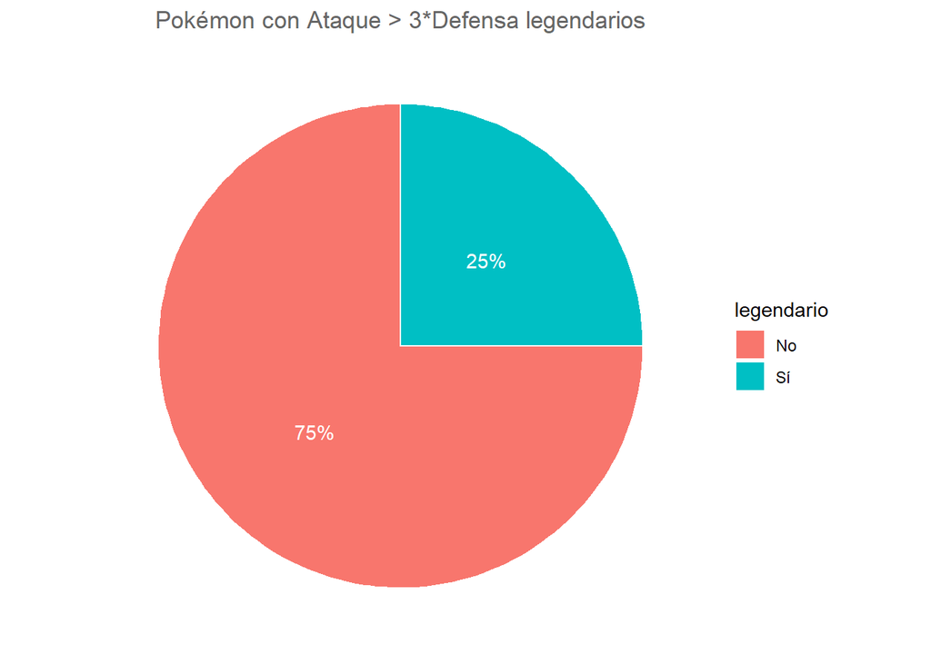

```r
a <-pokemon %>% filter(attack > 3*defense) %>%
  mutate(legendario = ifelse(is_legendary == 0,"No","Sí")) %>%
  group_by(legendario) %>% summarise(n = n()) %>%
  mutate(frec = n/sum(n))


pie(a,"Pokémon con Ataque > 3*Defensa legendarios")
```

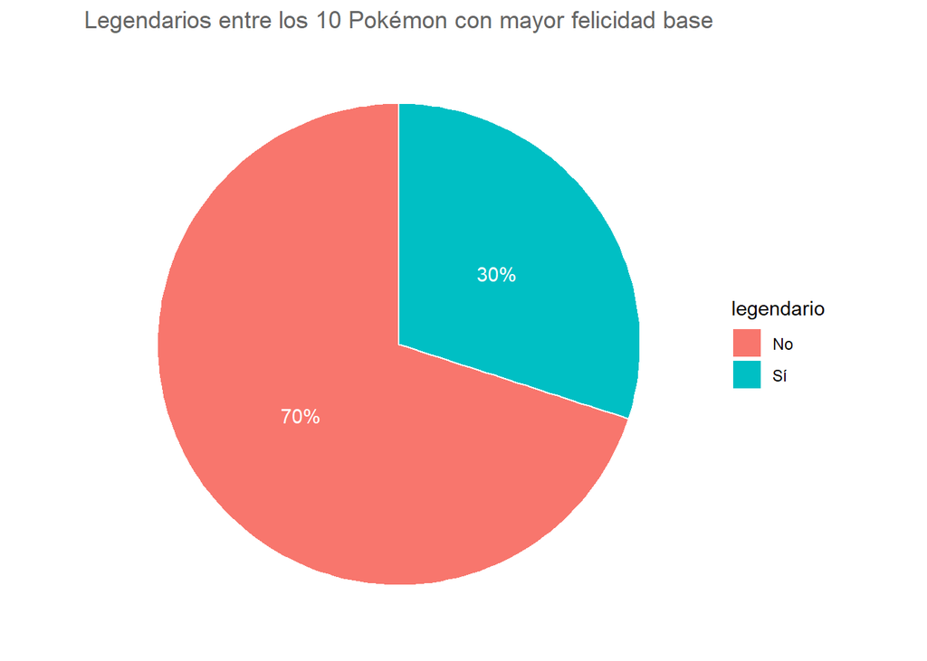

```r
b <-pokemon %>% arrange(-base_happiness) %>% head(10) %>%
  select(name,japanese_name,is_legendary) %>%
  mutate(legendario = ifelse(is_legendary == 0,"No","Sí")) %>%
  group_by(legendario) %>% summarise(n = n()) %>%
  mutate(frec = n/sum(n))

pie(b,"Legendarios entre los 10 Pokémon con mayor felicidad base")
```

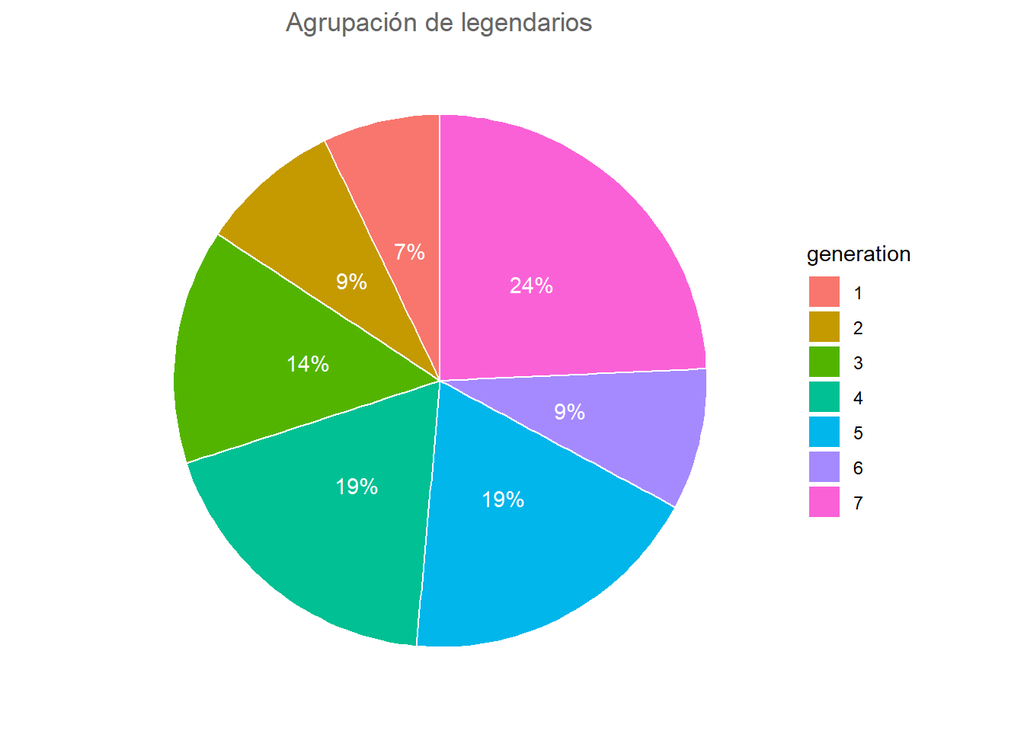

```r
c <- pokemon %>% filter(is_legendary == 1) %>% group_by(generation) %>%
  summarise(n = n()) %>% mutate(frec = n/sum(n))

pie(c,"Agrupación de legendarios")
```

# Pregunta 2: Recomendación de películas

Utilizando la versión ligera de “MovieLens”, una base de datos con información de calificaciones y etiquetados para aproximadamente 10.000 películas, responda las siguientes preguntas:

*Paso 1: Importamos bases de datos*

```r
links <- read_csv("links.csv")
movies <- read_csv("movies.csv")
tags <- read_csv("tags.csv")
ratings <- read_csv("ratings.csv")
```

## Punto 0

*Modifique el dataframe movies, separando el título y año de la película en distintas variables.*

```r
movies2 <- movies %>%
  mutate(year = str_replace_all(str_extract(title, "[(][0-9]{4}[)]"),"[()]",""),
         title = str_replace(title, "([(][0-9]{4}[)])","")
         )
```

## Punto 1

*Utilizando una medida arbitraria μ_Rating×Log(N° Ratings), muestre los títulos y puntajes obtenidos por película, ordenándolos descendentemente. Grafique el promedio anual de nuestra métrica para los últimos 20 años, considerando únicamente a aquellos regístros con una medida mayor a 0.*

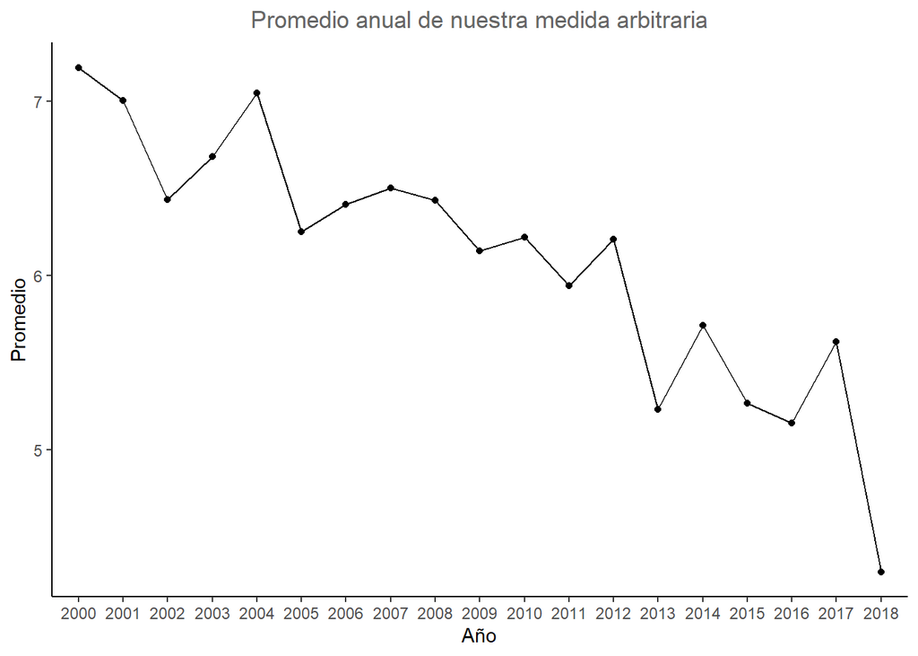

```r
p1 <- left_join(movies2,ratings, by="movieId") %>% group_by(title) %>%
  summarise(year = first(year),
            medida = round(mean(rating, na.rm=1)*log(n()),2)) %>% arrange(-medida)

p2 <- p1 %>% filter(year >= 2000 & medida >0) %>% group_by(year) %>%
  summarise(promedio  = mean(medida,na.rm = 1)) %>%
  ggplot(aes(x = year, y = promedio, group = 1)) + geom_line() + geom_point() +
  theme_classic() +
  labs(x = "Año", y = "Promedio", title = "Promedio anual de nuestra medida arbitraria") +
  theme(plot.title = element_text(hjust = 0.5, color = "#666666"))

p2
```

## Punto 2

Obtenga los nombres de las 10 películas con mayor cantidad de votaciones en la categoría comedia. Grafique

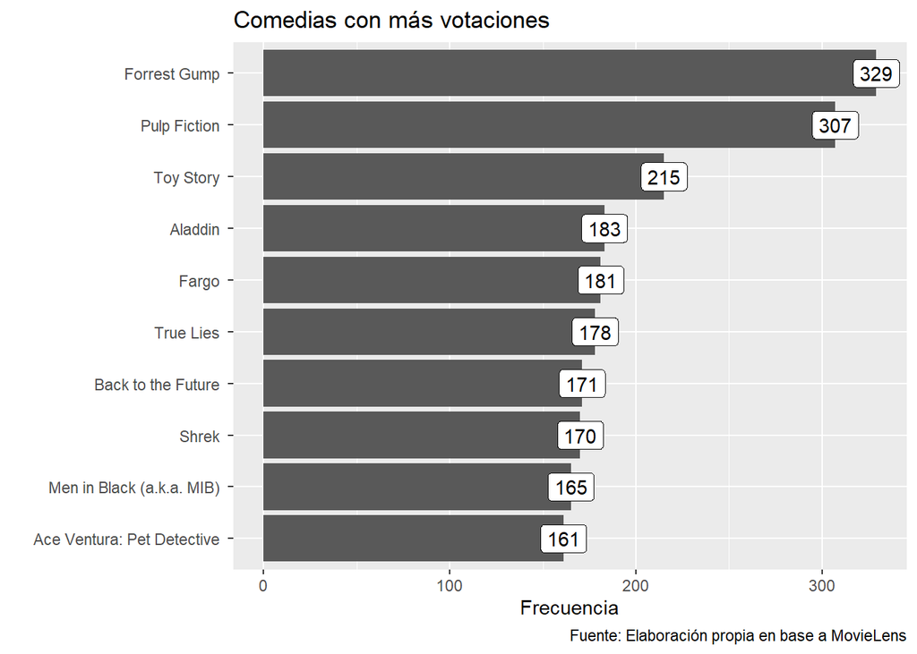

```r
movies2 %>% filter(str_detect(genres,"Comedy")) %>%
  left_join(ratings, by ="movieId") %>% group_by(movieId) %>%
  summarise(title = first(title),n = n()) %>% arrange(-n) %>%
  head(10) %>%
  ggplot(mapping = aes(x = n, y = fct_reorder(as.factor(title), n), label = n)) +
  geom_colh() +   geom_label() +
  labs(title    = "Comedias con más votaciones",
       x = "Frecuencia", y = "",
       caption  = "Fuente: Elaboración propia en base a MovieLens")
```

## Punto 3

Obtenga los títulos, calificación promedio y géneros de las 10 mejores películas de animación no infantil producidas dentro de los últimos 3 años. Utilice solo el rating. Posteriormente, grafique la calificación promedio de dichas películas.

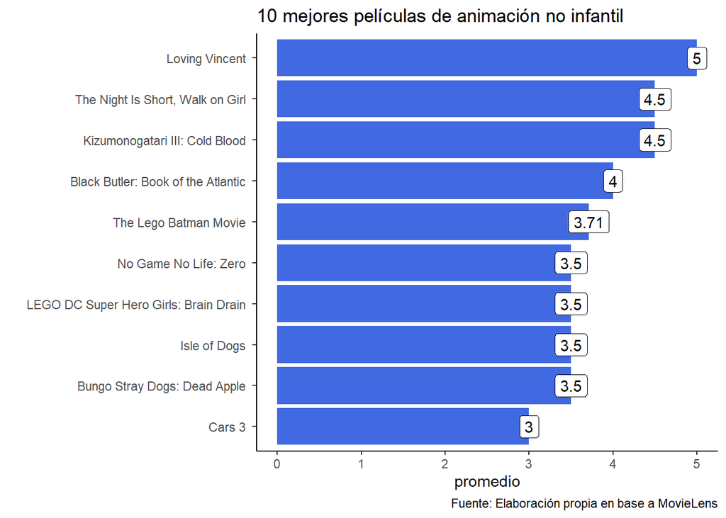

```r
p1 <- ratings %>% group_by(movieId) %>% summarise(promedio = round(mean(rating),2)) %>%
  left_join(movies2, by ="movieId") %>%
  filter(str_detect(genres,"Animation") &
                     !str_detect(genres,"Children") &
                     year >= 2017) %>%
  arrange(-promedio) %>% head(10) %>%
  select(title, promedio, genres)

#Graficamos
p2 <- p1 %>%
  ggplot(mapping = aes(x = promedio, y = fct_reorder(as.factor(title), promedio), label = promedio)) +
  geom_colh(fill = "royalblue") +   geom_label() + theme_classic() +
  labs(title    = "10 mejores películas de animación no infantil",
       x = "promedio", y = "",
       caption  = "Fuente: Elaboración propia en base a MovieLens")
p2
```

## Punto 4

Muestre el título, etiqueta más común y rating promedio de aquellos 10 registros de películas con un etiquetado más consistente (con más repeticiones).

```r
p1 <- left_join(tags %>% group_by(movieId,tag) %>% count(sort = T) %>% head(10),
          ratings %>% group_by(movieId) %>% summarise(promedio = round(mean(rating),2)),
          by="movieId") %>%
  left_join(movies2, by = "movieId") %>% ungroup() %>%
  select(title,tag,promedio) %>% arrange(-promedio)

p2 <-   p1 %>% kable(caption = "Tabla 4: 10 registros con etiquetado más consistente",
        digits = 2, align = "l",
        col.names = c("Título","Etiqueta","Promedio")) %>%
  kable_styling("striped", full_width = T) %>%
  footnote(general = "Elaboración propia en base a MovieLens",
           title_format = c("italic", "underline"),
           general_title = "Fuente: ")

p2
```

Tabla 4: 10 registros con etiquetado más consistente

| Título | Etiqueta | Promedio |
| --- | --- | --- |
| Dr. Strangelove or: How I Learned to Stop Worrying and Love the Bomb | dark comedy | 4.27 |
| Fight Club | dark comedy | 4.27 |
| Star Wars: Episode IV - A New Hope | classic sci-fi | 4.23 |
| Star Wars: Episode IV - A New Hope | sci-fi | 4.23 |
| Memento | twist ending | 4.12 |
| Twelve Monkeys (a.k.a. 12 Monkeys) | time travel | 3.98 |
| Donnie Darko | dreamlike | 3.98 |
| Donnie Darko | hallucinatory | 3.98 |
| Step Brothers | funny | 3.55 |
| Step Brothers | will ferrell | 3.55 |

Fuente:  
Elaboración propia en base a MovieLens

*Inception y Dr.Strangelove tienen el mismo n, por eso cambian dependiendo del orden

## Propuesto 1

*Obtenga las 50 películas con menor calificación promedio según los 3 usuario que han escrito más reseñas.*

## Propuesto 2

*Utilizando la medida arbitraria descrita en el ejercicio 1 y, considerando las 100 mejores películas según ésta, obtenga las 5 etiquetas más repetidas en sus descripciones.*